# Prediction Assignment Writeup

Claudio Torres Casanelli

27-01-2021

## Introduction

Using devices such as Jawbone Up, Nike FuelBand, and Fitbit it is now possible to collect a large amount of data about personal activity relatively inexpensively. These type of devices are part of the quantified self movement – a group of enthusiasts who take measurements about themselves regularly to improve their health, to find patterns in their behavior, or because they are tech geeks. One thing that people regularly do is quantify how much of a particular activity they do, but they rarely quantify how well they do it. In this project, your goal will be to use data from accelerometers on the belt, forearm, arm, and dumbell of 6 participants. They were asked to perform barbell lifts correctly and incorrectly in 5 different ways. More information is available from the website here: http://web.archive.org/web/20161224072740/http:/groupware.les.inf.puc-rio.br/har (see the section on the Weight Lifting Exercise Dataset).

## Analysis of the data

I now start loading the data from the csv files and store them in two variables: training and testing.

```r
training <- read.csv("pml-training.csv", na.strings=c("NA", ""))
training <- training[,colSums(is.na(training)) == 0]
training <- training[, -c(1,2,3,4,5,6,7)]
training$classe <- as.factor(training$classe)
ncol(training)
```

```
## [1] 53
```

```r
testing <- read.csv("pml-testing.csv", na.strings=c("NA", ""))
testing <- testing[,colSums(is.na(testing)) == 0]
testing <- testing[, -c(1,2,3,4,5,6,7)]
ncol(testing)
```

```
## [1] 53
```

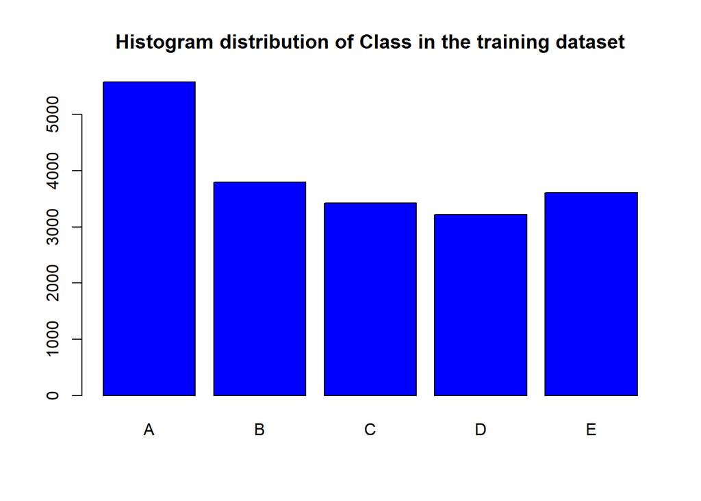

```r
set.seed(23125)

prePCA <- preProcess(training,method="pca",thresh=.95)
training <- predict(prePCA, training)
testing <- predict(prePCA, testing)

plot(as.factor(training$classe), main="Histogram distribution of Class in the training dataset", col="blue")
```

```r
ctrl <- trainControl(method = "cv", number = 5)
cvmodel <- train(classe~., data = training, method = "rpart", trControl = ctrl)
cvmodel$finalModel
```

```
## n= 19622
##
## node), split, n, loss, yval, (yprob)
##       * denotes terminal node
##
## 1) root 19622 14042 A (0.28 0.19 0.17 0.16 0.18)
##   2) PC14>=-0.916215 17652 12134 A (0.31 0.19 0.19 0.17 0.14)
##     4) PC8< 1.348972 14627  9482 A (0.35 0.17 0.22 0.12 0.14) *
##     5) PC8>=1.348972 3025  1767 D (0.12 0.24 0.051 0.42 0.17) *
##   3) PC14< -0.916215 1970   887 E (0.031 0.26 0.029 0.13 0.55) *
```

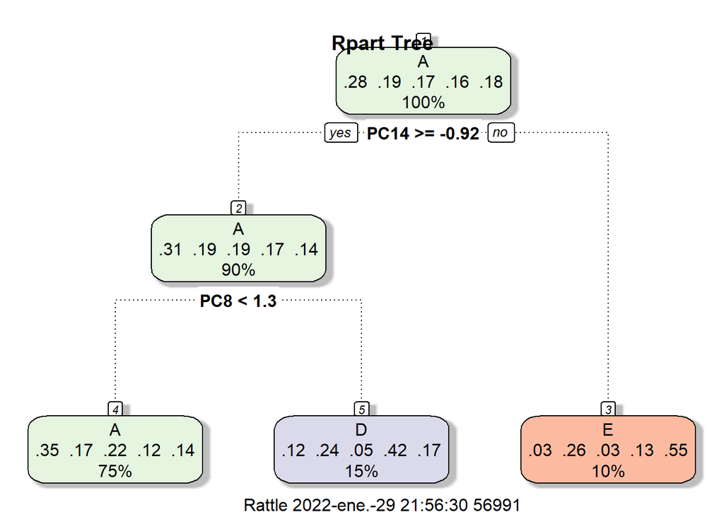

```r
fancyRpartPlot(cvmodel$finalModel, main="Rpart Tree")
```

## Fitting a Model

Here I generate models and train the training data set to choose a model to do the final predictions. No need to argue so much about the chosen model. Random Forest is the chosen one. Below is the evidence.

```r
TrainSelect <- createDataPartition(y=training$classe, p=0.8, list=FALSE)
TrainSelectModel <- training[TrainSelect, ]
TestSelectModel <- training[-TrainSelect, ]

modelRPART <- rpart(classe~., data=TrainSelectModel, method ="class")
predRPART <- predict(modelRPART, TestSelectModel, type="class")
confusionMatrix(predRPART, TestSelectModel$classe)
```

```
## Confusion Matrix and Statistics
##
##           Reference
## Prediction   A   B   C   D   E
##          A 832 259 200 170 117
##          B  21 125   8  17  65
##          C 179 133 403  93 108
##          D  61 101  30 242  48
##          E  23 141  43 121 383
##
## Overall Statistics
##
##                Accuracy : 0.506
##                  95% CI : (0.4902, 0.5218)
##     No Information Rate : 0.2845
##     P-Value [Acc > NIR] : < 2.2e-16
##
##                   Kappa : 0.3665
##
##  Mcnemar's Test P-Value : < 2.2e-16
##
## Statistics by Class:
##
##                      Class: A Class: B Class: C Class: D Class: E
## Sensitivity            0.7455  0.16469   0.5892  0.37636  0.53121
## Specificity            0.7342  0.96492   0.8416  0.92683  0.89756
## Pos Pred Value         0.5272  0.52966   0.4400  0.50207  0.53868
## Neg Pred Value         0.8789  0.82804   0.9066  0.88346  0.89477
## Prevalence             0.2845  0.19347   0.1744  0.16391  0.18379
## Detection Rate         0.2121  0.03186   0.1027  0.06169  0.09763
## Detection Prevalence   0.4022  0.06016   0.2335  0.12287  0.18124
## Balanced Accuracy      0.7399  0.56480   0.7154  0.65160  0.71439
```

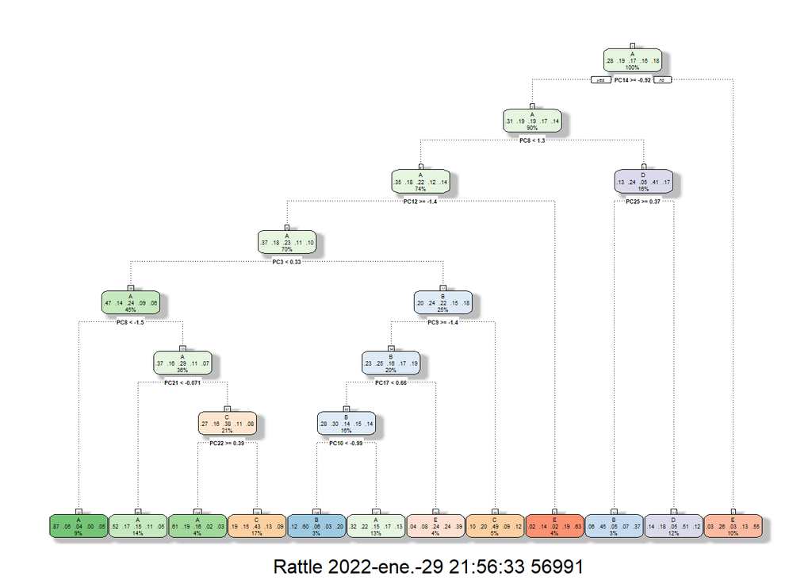

```r
fancyRpartPlot(modelRPART)
```

```r
modelRF <- randomForest(classe~., data=TrainSelectModel, method ="class")
predRF <- predict(modelRF, TestSelectModel, type="class")

confusionMatrix(predRF, TestSelectModel$classe)
```

```
## Confusion Matrix and Statistics
##
##           Reference
## Prediction    A    B    C    D    E
##          A 1107   15    0    2    0
##          B    2  732    5    0    1
##          C    3   12  671   18    9
##          D    2    0    7  622    2
##          E    2    0    1    1  709
##
## Overall Statistics
##
##                Accuracy : 0.9791
##                  95% CI : (0.9741, 0.9833)
##     No Information Rate : 0.2845
##     P-Value [Acc > NIR] : < 2.2e-16
##
##                   Kappa : 0.9736
##
##  Mcnemar's Test P-Value : NA
##
## Statistics by Class:
##
##                      Class: A Class: B Class: C Class: D Class: E
## Sensitivity            0.9919   0.9644   0.9810   0.9673   0.9834
## Specificity            0.9939   0.9975   0.9870   0.9966   0.9988
## Pos Pred Value         0.9849   0.9892   0.9411   0.9826   0.9944
## Neg Pred Value         0.9968   0.9915   0.9960   0.9936   0.9963
## Prevalence             0.2845   0.1935   0.1744   0.1639   0.1838
## Detection Rate         0.2822   0.1866   0.1710   0.1586   0.1807
## Detection Prevalence   0.2865   0.1886   0.1817   0.1614   0.1817
## Balanced Accuracy      0.9929   0.9809   0.9840   0.9820   0.9911
```

Finally, now that we have chosen the Random Forest model, I am going to do the prediction on the original Testing data set.

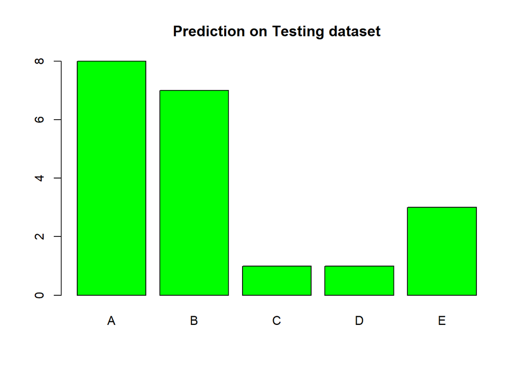

```r
predTesting <- predict(modelRF, testing)
plot(predTesting, col="green", main="Prediction on Testing dataset")
```

```r
predTesting
```

```
##  1  2  3  4  5  6  7  8  9 10 11 12 13 14 15 16 17 18 19 20
##  B  A  A  A  A  E  D  B  A  A  B  C  B  A  E  E  A  B  B  B
## Levels: A B C D E
```